# Part 2: Analysis of Pancake Swap APR

## R Markdown

An interesting application of the result of the preceding part is the calculation of the farm *APR* of **PancakeSwap** liquidity mining program. The *APR(Annual Percentage Rate)* represents the yield obtained from staking funds on a certain pool (without considering the composability).

How is it calculated? Analyzing [the code](https://github.com/pancakeswap/pancake-frontend/blob/develop/src/utils/apr.ts) we can see that is done as follows:

$$APR = \text{CAKES MINTED PER YEAR}\times \frac{\text{POOL WEIGHT}}{\text{TOTAL POOL LIQUIDITY}} \times \text{CAKE PRICE}$$

First of all, from the [Pancake Swap documentation](https://docs.pancakeswap.finance/tokenomics/cake/cake-tokenomics) we read that for each BSC block, $40$ cakes are minted, $10$ of which are given to farms. Given that in BSC a block is mined every 3 seconds, we get that the CAKES given to farms every year are:

$$\text{CAKES MINTED PER YEAR} = \text{BLOCKS PER YEAR} \times \text{CAKES PER BLOCK}$$

```r
CAKE_PER_BLOCK = 10
BSC_BLOCK_TIME = 3
BLOCKS_PER_YEAR = (60 / BSC_BLOCK_TIME) * 60 * 24 * 365

CAKE_PER_YEAR = BLOCKS_PER_YEAR * CAKE_PER_BLOCK
```

The pool weight is, on the other hand, a *constant* chosen by the developers for each pool. Considering that the *CAKES* minted and the pool weight are actually *constants*, we can rewrite the formula as:

$$APR = k\,\,\frac{\text{CAKE PRICE}}{\text{TOTAL POOL LIQUIDITY}}$$

With this in mind, here we define the functions to calculate the APR given the list of the transactions of a certain smart contract. To see how the database of the transactions is obtained, refer to this [Python script](https://github.com/fradeca01/DeFi-Tvl-Analysis/blob/main/download_pswap_db.py).

```r
getContractTokenLiquidity = function(conn, token, address){

  token = tolower(token)


  res = dbGetQuery(conn, "SELECT * FROM transactions")

  transactions = as_tibble(res)

  transactions = transactions %>%
    select(blockNumber, timeStamp, fromAddr, toAddr, tokenSymbol, value) %>%
    mutate(dateTime = lubridate::as_datetime(as.integer(timeStamp))) %>%
    mutate(tokenSymbol = tolower(tokenSymbol)) %>%
    arrange(blockNumber)

  outTib = transactions %>%
    filter(tokenSymbol == token) %>%
    filter(fromAddr == address) %>%
    select(blockNumber, dateTime, value)%>%
    group_by(blockNumber, dateTime) %>%
    summarise(value = sum(value), .groups = "drop") %>%
    arrange(blockNumber)

  inTib = transactions %>%
    filter(tokenSymbol == token) %>%
    filter(toAddr == address) %>%
    group_by(blockNumber, dateTime) %>%
    summarise(value = sum(value), .groups = "drop") %>%
    arrange(blockNumber)

  liquidity = full_join(outTib, inTib, by=c("blockNumber", "dateTime"),suffix = c("Out", "In")) %>%
    tidyr::replace_na(list(valueOut = 0, valueIn = 0)) %>%
    mutate(blockBalance = valueIn - valueOut) %>%
    arrange(blockNumber) %>%
    mutate(totBalance = cumsum(blockBalance)) %>%
    mutate(date = lubridate::as_date(dateTime), time = hms::as_hms(dateTime), hour = as.POSIXlt(dateTime)$hour) %>%
    select(blockNumber, dateTime, date, time, hour, totBalance)
}

convertLiquidityToUsd = function (liquidityToken, priceToken){

  liquidityTokenUSD = priceToken %>%
    select(date, hour, price) %>%
    right_join(liquidityToken, by=c("date", "hour")) %>%
    mutate(liquidityUSD = totBalance * price) %>%
    select(blockNumber, dateTime, date, time, hour, liquidityUSD)

  liquidityT2USD = priceToken %>%
    select(date, hour, price) %>%
    right_join(liquidityToken, by=c("date", "hour"))  %>%
    mutate(liquidityUSD = totBalance * price) %>%
    select(blockNumber,dateTime, date, time, hour, liquidityUSD)
}
```

```r
open_database = function(address, path){
  DBaddress = paste("DB-", address, sep="")

  con = RSQLite::dbConnect(RSQLite::SQLite(), paste(path,"/",DBaddress, sep=""))
}

getContractTokensName = function(address, path){

  conn = open_database(address, path)

  res = dbGetQuery(conn, "SELECT tokenSymbol from transactions GROUP BY tokenSymbol ORDER BY count(tokenSymbol) DESC LIMIT 2")

  dbDisconnect(conn)

  res$tokenSymbol
}


getTotalLiquidity = function(address, tokens, path){

  #Parameters:
  #  -address of pool smart contract
  #  -pool multiplier

  #Returns:
  #  -Tibble for the APR over time

  #STEP 1 open database
  conn = open_database(address, path)

  address = tolower(address)

  #STEP 3 get the liquidity of the tokens
  liquidityT1 = getContractTokenLiquidity(conn, tokens[1], address)
  liquidityT2 = getContractTokenLiquidity(conn, tokens[2], address)

  #STEP 4 get the coingecko ids of the pool tokens and cake
  id1 = get_token_id(tolower(tokens[1]))[1]
  id2 = get_token_id(tolower(tokens[2]))[1]

  #STEP 5 get the price of the pool tokens and cake
  priceTibbleT1 = get_token_price(id1, 90, "hourly")
  priceTibbleT2 = get_token_price(id2, 90, "hourly")


  #STEP 6 calculate the liquidity of tokens in USD
  liquidityT1USD = convertLiquidityToUsd(liquidityT1, priceTibbleT1)
  liquidityT2USD = convertLiquidityToUsd(liquidityT2, priceTibbleT2)

  liquidityPool = inner_join(liquidityT1USD, liquidityT2USD, by=c("blockNumber",   "dateTime", "date", "time", "hour")) %>%
    mutate(totLiquidity = liquidityUSD.x + liquidityUSD.y) %>%
    arrange(blockNumber)

  dbDisconnect(conn)

  liquidityPool
}

getApr = function(liquidityPool, pool_multiplier){

  cakeID = get_token_id("cake")

  cakeTibble = get_token_price(cakeID, 90, "hourly")

  #STEP 7 calculate the APR of the pool
  pool_weight = pool_multiplier/147.7

  APRTib = liquidityPool %>%
    select(blockNumber, dateTime, date, time, hour, totLiquidity) %>%
    left_join(select(cakeTibble, date, hour, price), by = c("date", "hour")) %>%
    rename(cakePrice = price) %>%
    mutate(APR = 100 * cakePrice * CAKE_PER_YEAR * pool_weight / totLiquidity)

  APRTib
}
```

In [Part 1](https://github.com/fradeca01/DeFi-Tvl-Analysis/blob/main/Part1-TVL.html) we saw that the *TVL* of **Pancake Swap** is proportional to the price of *BNB*. If we assume that this holds also for the *Total Pool Liquidity* of each pool, which is eventually a fraction of the *TVL*, we obtain:

$$APR \,\propto \,\frac{CAKE}{BNB}$$

Now, we analyze the price of CAKE against the one of BNB:

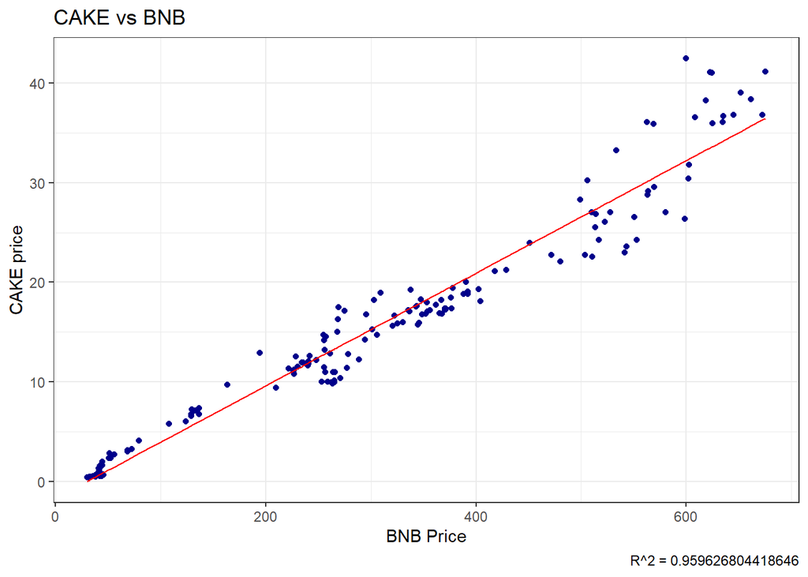

```r
cakeID = get_token_id("cake")
bnbID = get_token_id("bnb")

cake = get_token_price(cakeID, 180, "daily")%>%
  select(date, price)
bnb = get_token_price(bnbID, 180, "daily")%>%
  select(date, price)

cakebnb = inner_join(cake, bnb, by="date", suffix=c("cake", "bnb"))

# ggplot(cakebnb) +
#   geom_point(aes(pricebnb, pricecake))

mod = lm(data = cakebnb, pricecake ~ pricebnb)

cakebnb = add_predictions(cakebnb, mod)

r2 = cor(cakebnb$pricebnb, cakebnb$pricecake)^2

plot0 = ggplot(cakebnb) +
  geom_point(aes(pricebnb, pricecake), color="darkblue") +
  geom_line(aes(pricebnb, pred), color="red")+
  labs(title = "CAKE vs BNB", caption = paste("R^2 =", r2)) +
  xlab("BNB Price") +
  ylab("CAKE price") +
  theme_bw()

plot0
```

```r
r2
```

```
## [1] 0.9596268
```

What we obtained is that $R^2 \approx 0.96$. The *BNB* price and the *CAKE* price has been strongly correlated during last year, i.e. $CAKE =k\, BNB$. Plugging this result in last formula we obtain that the APR should has been approximately constant.

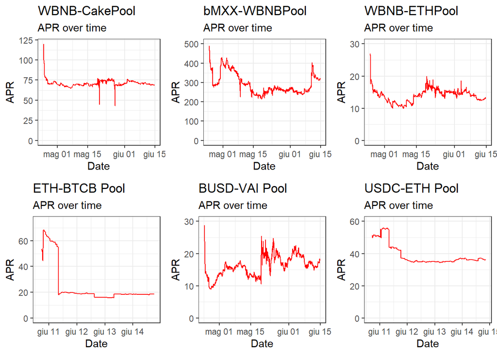

```r
#Write here the path of your DBs
path = "DBs"

#Address of Smart Contract
address = "0x0eD7e52944161450477ee417DE9Cd3a859b14fD0"
multiplier = 40

tokens = getContractTokensName(address, path)
liquidityPool = getTotalLiquidity(address, tokens, path)
apr = getApr(liquidityPool, multiplier)

plot1 = ggplot(data = filter(apr, APR<600)) +
  geom_line(mapping = aes(x=dateTime, y = APR), color="red") +
  labs(title = paste(tokens[1],"-",tokens[2],"Pool", sep=""), subtitle = "APR over time")+
  xlab("Date")+
  scale_y_continuous(limits=c(0,120))+
  ylab("APR")+
  theme_bw()

#Address of Smart Contacrt
address = "0xc20A92a1424b29b78DFaF92FD35D4cf8A06419B4"
multiplier = 1

tokens = getContractTokensName(address, path)
liquidityPool = getTotalLiquidity(address, tokens, path)
apr = getApr(liquidityPool, multiplier)

plot2 = ggplot(data = filter(apr, APR<600)) +
  geom_line(mapping = aes(x=dateTime, y = APR), color="red") +
  labs(title = paste(tokens[1],"-",tokens[2],"Pool", sep=""), subtitle = "APR over time")+
  xlab("Date")+
  scale_y_continuous(limits=c(0,500))+
  ylab("APR")+
  theme_bw()

#Address of Smart Contacrt
address = "0x74E4716E431f45807DCF19f284c7aA99F18a4fbc"
multiplier = 2

tokens = getContractTokensName(address, path)
liquidityPool = getTotalLiquidity(address, tokens, path)
apr = getApr(liquidityPool, multiplier)

plot3 = ggplot(data = filter(apr, APR<600)) +
  geom_line(mapping = aes(x=dateTime, y = APR), color="red") +
  labs(title = paste(tokens[1],"-",tokens[2],"Pool", sep=""), subtitle = "APR over time")+
  xlab("Date")+
  scale_y_continuous(limits=c(0,30))+
  ylab("APR")+
  theme_bw()

address = "0xD171B26E4484402de70e3Ea256bE5A2630d7e88D"
multiplier = 2

tokens = getContractTokensName(address, path)
liquidityPool = getTotalLiquidity(address, tokens, path)
apr = getApr(liquidityPool, multiplier)

plot4 = ggplot(data = filter(apr, APR<600)) +
  geom_line(mapping = aes(x=dateTime, y = APR), color="red") +
  labs(title = paste(tokens[1],"-",tokens[2]," Pool", sep=""), subtitle = "APR over time")+
  xlab("Date")+
  scale_y_continuous(limits=c(0,75))+
  ylab("APR")+
  theme_bw()

address = "0x133ee93FE93320e1182923E1a640912eDE17C90C"
multiplier = 0.5

tokens = getContractTokensName(address, path)
liquidityPool = getTotalLiquidity(address, tokens, path)
apr = getApr(liquidityPool, multiplier)

plot5 = ggplot(data = filter(apr, APR<600)) +
  geom_line(mapping = aes(x=dateTime, y = APR), color="red") +
  labs(title = paste(tokens[1],"-",tokens[2]," Pool", sep=""), subtitle = "APR over time")+
  xlab("Date")+
  scale_y_continuous(limits=c(0,30))+
  ylab("APR")+
  theme_bw()

address = "0xEa26B78255Df2bBC31C1eBf60010D78670185bD0"
multiplier = 1

tokens = getContractTokensName(address, path)
liquidityPool = getTotalLiquidity(address, tokens, path)
apr = getApr(liquidityPool, multiplier)

plot6 = ggplot(data = filter(apr, APR<600)) +
  geom_line(mapping = aes(x=dateTime, y = APR), color="red") +
  labs(title = paste(tokens[1],"-",tokens[2]," Pool", sep=""), subtitle = "APR over time")+
  xlab("Date")+
  scale_y_continuous(limits=c(0,60))+
  ylab("APR")+
  theme_bw()

plot_grid(plot1, plot2, plot3, plot4, plot5, plot6)
```

```r
aprPlots=list(plot0, plot1, plot2, plot3, plot4, plot5, plot6)
```

As in Part 1, we save the result of analysis in a *.rds* file:

```r
saveRDS(aprPlots, "aprPlots.rds")
```